# p8105_hw6_yc4585

2024-12-02

# Problem2

## Import and clean data

```r
omit_cities <- c("Dallas, TX", "Phoenix, AZ",
                 "Kansas City, MO", "Tulsa, AL")


homi_data <- read_csv("../homicide-data.csv",na = c("", "NA", "Unknown")) |>
  mutate(
    city_state = paste(city, state, sep = ", "),
    victim_age = as.numeric(victim_age),
    solved = case_when(
      str_detect(disposition, "Closed by arrest") ~ 1,
      str_detect(disposition, "Closed without arrest") ~ 0,
      str_detect(disposition, "Open/No arrest") ~ 0
    )
  ) |>
  filter(
    !city_state %in% c("Dallas, TX", "Phoenix, AZ",
                       "Kansas City, MO", "Tulsa, AL"),
    victim_race %in% c("White", "Black")
  ) |>
  filter(!is.na(victim_age))
```

## Logistic regression

```r
md_data = homi_data |>
  filter(city_state == "Baltimore, MD")

model = glm(
  solved ~ victim_age + victim_sex + victim_race,
  data = md_data,
  family = binomial
) |>
  broom::tidy() |>
  mutate(
    OR = exp(estimate),
    ci_lower = exp(estimate - 1.96 * std.error),
    ci_upper = exp(estimate + 1.96 * std.error)
  )


male_vs_female = model |>
  filter(term == "victim_sexMale") |>
  select(term,OR,ci_lower,ci_upper) |>
  knitr::kable(digits = 3)

print(male_vs_female)
```

```
##
##
## |term           |    OR| ci_lower| ci_upper|
## |:--------------|-----:|--------:|--------:|
## |victim_sexMale | 0.426|    0.325|    0.558|
```

## Log regression for each city

```r
city_models = homi_data |>
  nest(data=-city_state) |>
  mutate(
    model = map(data, ~ glm(
      solved ~ victim_age + victim_sex + victim_race,
      data = .x,
      family = binomial
    )),
    tidy_model = map(model, broom::tidy)) |>
  select(-data, -model) |>
  unnest(tidy_model) |>
  filter(term == "victim_sexMale") |>
  mutate(
    OR = exp(estimate),
    ci_lower = exp(estimate - 1.96 * std.error),
    ci_upper = exp(estimate + 1.96 * std.error)
  ) |>
  select(city_state,OR,ci_lower,ci_upper)

city_models |>
  knitr::kable(digits = 3)
```

| city_state | OR | ci_lower | ci_upper |
| --- | --- | --- | --- |
| Albuquerque, NM | 1.767 | 0.831 | 3.761 |
| Atlanta, GA | 1.000 | 0.684 | 1.463 |
| Baltimore, MD | 0.426 | 0.325 | 0.558 |
| Baton Rouge, LA | 0.381 | 0.209 | 0.695 |
| Birmingham, AL | 0.870 | 0.574 | 1.318 |
| Boston, MA | 0.667 | 0.354 | 1.260 |
| Buffalo, NY | 0.521 | 0.290 | 0.935 |
| Charlotte, NC | 0.884 | 0.557 | 1.403 |
| Chicago, IL | 0.410 | 0.336 | 0.501 |
| Cincinnati, OH | 0.400 | 0.236 | 0.677 |
| Columbus, OH | 0.532 | 0.378 | 0.750 |
| Denver, CO | 0.479 | 0.236 | 0.971 |
| Detroit, MI | 0.582 | 0.462 | 0.734 |
| Durham, NC | 0.812 | 0.392 | 1.683 |
| Fort Worth, TX | 0.669 | 0.397 | 1.127 |
| Fresno, CA | 1.335 | 0.580 | 3.071 |
| Houston, TX | 0.711 | 0.558 | 0.907 |
| Indianapolis, IN | 0.919 | 0.679 | 1.242 |
| Jacksonville, FL | 0.720 | 0.537 | 0.966 |
| Las Vegas, NV | 0.837 | 0.608 | 1.154 |
| Long Beach, CA | 0.410 | 0.156 | 1.082 |
| Los Angeles, CA | 0.662 | 0.458 | 0.956 |
| Louisville, KY | 0.491 | 0.305 | 0.790 |
| Memphis, TN | 0.723 | 0.529 | 0.988 |
| Miami, FL | 0.515 | 0.304 | 0.872 |
| Milwaukee, wI | 0.727 | 0.499 | 1.060 |
| Minneapolis, MN | 0.947 | 0.478 | 1.875 |
| Nashville, TN | 1.034 | 0.685 | 1.562 |
| New Orleans, LA | 0.585 | 0.422 | 0.811 |
| New York, NY | 0.262 | 0.138 | 0.499 |
| Oakland, CA | 0.563 | 0.365 | 0.868 |
| Oklahoma City, OK | 0.974 | 0.624 | 1.520 |
| Omaha, NE | 0.382 | 0.203 | 0.721 |
| Philadelphia, PA | 0.496 | 0.378 | 0.652 |
| Pittsburgh, PA | 0.431 | 0.265 | 0.700 |
| Richmond, VA | 1.006 | 0.498 | 2.033 |
| San Antonio, TX | 0.705 | 0.398 | 1.249 |
| Sacramento, CA | 0.669 | 0.335 | 1.337 |
| Savannah, GA | 0.867 | 0.422 | 1.780 |
| San Bernardino, CA | 0.500 | 0.171 | 1.462 |
| San Diego, CA | 0.413 | 0.200 | 0.855 |
| San Francisco, CA | 0.608 | 0.317 | 1.165 |
| St. Louis, MO | 0.703 | 0.530 | 0.932 |
| Stockton, CA | 1.352 | 0.621 | 2.942 |
| Tampa, FL | 0.808 | 0.348 | 1.876 |
| Tulsa, OK | 0.976 | 0.614 | 1.552 |
| Washington, DC | 0.691 | 0.469 | 1.018 |

## Plot that shows the estimated ORs and CIs for each city

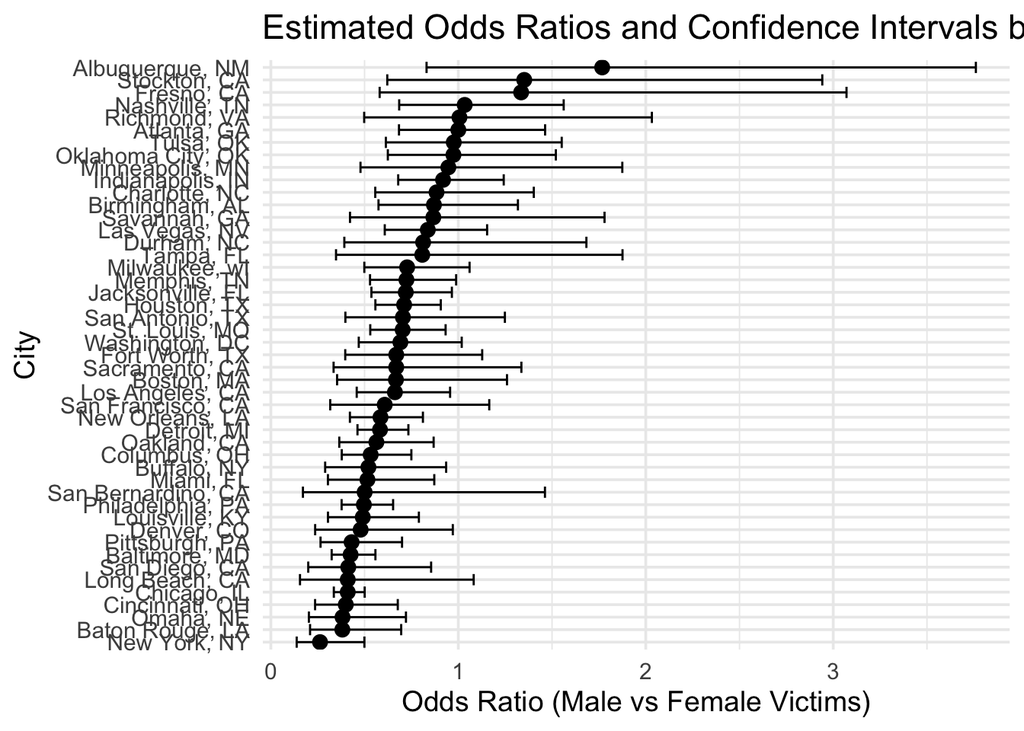

```r
or_results = city_models |>
  arrange(OR) |>
  mutate(city_state = factor(city_state, levels = city_state))

or_plot <- ggplot(or_results, aes(x = city_state, y = OR)) +
  geom_point(size = 3) +
  geom_errorbar(aes(ymin = ci_lower, ymax = ci_upper)) +
  coord_flip() +
  labs(
    title = "Estimated Odds Ratios and Confidence Intervals by City",
    x = "City",
    y = "Odds Ratio (Male vs Female Victims)"
  ) +
  theme_minimal(base_size = 14)

or_plot
```

An odds ratio of 1 indicates that cases of male or female victims are equally likely to be solved. An OR greater than 1 suggests that male victims are more likely to have their cases solved. From the plot, we observe that overall, the OR is less than 1, indicating that male victims are generally less likely to have their cases solved. However, in Albuquerque, Fresno, and Stockton, cases involving male victims show a higher likelihood of being solved. Nonetheless, the confidence intervals for these locations are relatively wide, implying that the estimates may lack precision.

# Problem3

## Import and clean data

```r
bw_data=read_csv("../birthweight.csv") |>
  janitor::clean_names() |>
  mutate(
    babysex = factor(babysex,levels=c(1,2),labels = c("Male", "Female")),
    frace = factor(frace, levels = c(1, 2, 3, 4, 8, 9),
                   labels = c("White", "Black", "Asian", "Puerto Rican", "Other", "Unknown")),
    mrace = factor(mrace, levels = c(1, 2, 3, 4, 8),
                   labels = c("White", "Black", "Asian", "Puerto Rican", "Other")),
    malform = factor(malform, labels = c("Absent", "Present")),
    smoken = factor(ifelse(smoken == 0, "Non-smoker", "Smoker"),
                    levels = c("Non-smoker", "Smoker")),
    parity = factor(parity),
    pnumlbw = factor(pnumlbw),
    pnumsga = factor(pnumsga)
  )

colSums(is.na(bw_data))
```

```
##  babysex    bhead  blength      bwt    delwt  fincome    frace  gaweeks
##        0        0        0        0        0        0        0        0
##  malform menarche  mheight   momage    mrace   parity  pnumlbw  pnumsga
##        0        0        0        0        0        0        0        0
##    ppbmi     ppwt   smoken   wtgain
##        0        0        0        0
```

There is no missing data in the dataset

## Regression model for birthweight

```r
numeric_vars <- bw_data |>
  select(where(is.numeric))

cor_matrix <- numeric_vars |>
  cor(use = "complete.obs")

cor_with_bwt <- cor_matrix |>
  as.data.frame() |>
  rownames_to_column(var = "Variable") |>
  pivot_longer(-Variable, names_to = "Target", values_to = "Correlation") |>
  filter(Target == "bwt" & Variable != "bwt") |>
  arrange(desc(abs(Correlation)))

cor_with_bwt
```

```
## # A tibble: 11 × 3
##    Variable Target Correlation
##    <chr>    <chr>        <dbl>
##  1 bhead    bwt         0.747
##  2 blength  bwt         0.743
##  3 gaweeks  bwt         0.412
##  4 delwt    bwt         0.288
##  5 wtgain   bwt         0.247
##  6 mheight  bwt         0.192
##  7 ppwt     bwt         0.183
##  8 fincome  bwt         0.155
##  9 momage   bwt         0.136
## 10 ppbmi    bwt         0.0939
## 11 menarche bwt        -0.0244
```

```r
bw_model <- lm(bwt ~ bhead + blength + gaweeks
               + delwt, data = bw_data)

summary(bw_model)
```

```
##
## Call:
## lm(formula = bwt ~ bhead + blength + gaweeks + delwt, data = bw_data)
##
## Residuals:
##      Min       1Q   Median       3Q      Max
## -1155.18  -183.25    -9.65   176.21  2513.16
##
## Coefficients:
##               Estimate Std. Error t value Pr(>|t|)
## (Intercept) -6249.5265    95.3679 -65.531   <2e-16 ***
## bhead         135.8153     3.5021  38.781   <2e-16 ***
## blength        79.1451     2.0739  38.162   <2e-16 ***
## gaweeks        14.1812     1.4916   9.507   <2e-16 ***
## delwt           2.0402     0.1995  10.228   <2e-16 ***
## ---
## Signif. codes:  0 '***' 0.001 '**' 0.01 '*' 0.05 '.' 0.1 ' ' 1
##
## Residual standard error: 282.8 on 4337 degrees of freedom
## Multiple R-squared:  0.6954, Adjusted R-squared:  0.6951
## F-statistic:  2476 on 4 and 4337 DF,  p-value: < 2.2e-16
```

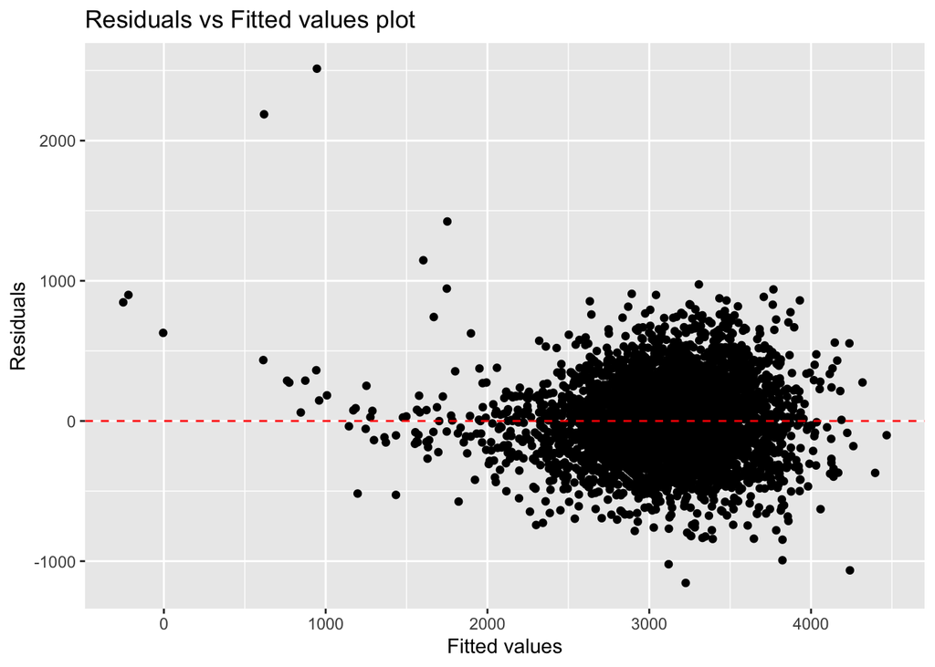

```r
data_with_preds_resids = bw_data |>
  modelr::add_predictions(bw_model) |>
  modelr::add_residuals(bw_model)

ggplot(data_with_preds_resids, aes(x = pred, y = resid)) +
  geom_point() +
  geom_hline(yintercept = 0, linetype = "dashed", color = "red") +
  labs(x = "Fitted values", y = "Residuals", title = "Residuals vs Fitted values plot")
```

I first select the numeric variables from the dataset. Then, I calculate the correlation matrix for these numeric variables to examine the relationships between them. After identifying the variables that show a strong correlation with birth weight (bwt), choose the most relevant ones to build the model. In this case,I use the variables head circumference (bhead), birth length (blength), gestational weeks (gaweeks), and delivered weight (delwt) to form the linear regression model.

In the plot of model residuals against fitted values, most of the residuals are symmetrically and evenly distributed around 0, which indicates homoscedasticity and suggests that the model fits the data well.

## Compare models

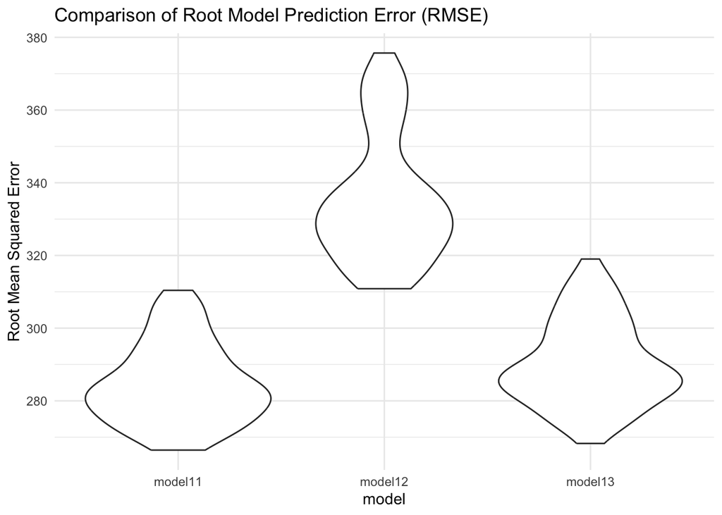

```r
cv_df =
  crossv_mc(bw_data, 100) |>
  mutate(
    train = map(train, as_tibble),
    test = map(test, as_tibble))

cv_model_error =
  cv_df |>
  mutate(
    model11  = map(train, ~lm(bwt ~ bhead + blength + gaweeks
                              + delwt,
                           data = .x)),
    model12  = map(train, ~lm(bwt ~ blength + gaweeks, data = .x)),
    model13  = map(train, ~lm(bwt ~ blength + bhead  + babysex +
                             bhead*blength + bhead*babysex + blength*babysex +
                             bhead*blength*babysex, data = .x))
  ) |>
  mutate(
    rmse_model11 = map2_dbl(model11, test, ~rmse(model = .x, data = .y)),
    rmse_model12 = map2_dbl(model12, test, ~rmse(model = .x, data = .y)),
    rmse_model13 = map2_dbl(model13, test, ~rmse(model = .x, data = .y))
  )



cv_model_error |>
  dplyr::select(starts_with("rmse")) |>
  pivot_longer(
    everything(),
    names_to = "model",
    values_to = "rmse",
    names_prefix = "rmse_") |>
  mutate(model = fct_inorder(model)) |>
  ggplot(aes(x = model, y = rmse)) +
  geom_violin() +
  theme_minimal() +
  labs(title = "Comparison of Root Model Prediction Error (RMSE)",
       y = "Root Mean Squared Error")
```

We can see that my model has a relatively smaller RMSE, indicating better predictive accuracy compared to other models.